# Network Analysis : London Tube

Krishna Kalyan

# Introduction

The aim of this assignment is to analyse the `london tube graph`. We will be using `igraph` library to build our network. This data is a simple pairwise connection between metro stations. Our data is contains 419 observations. This parwise connection is a directed graph.

# Analysis

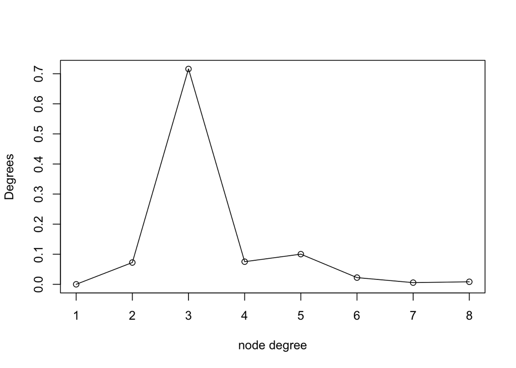

We know that real networks have a small diameter and high clustering co-efficient/ Transitivity. Transitivity measures the probability that the adjacent vertices of a vertex are connected. This is sometimes also called the clustering coefficient.

```r
diameter(metro_graph)
```

```
## [1] 37
```

```r
transitivity(metro_graph)
```

```
## [1] 0.04189944
```

### Graph Structure

Plotting the graph structure below we see a strucutre that a realword starion metro would be like. For example stations far out will be less connected that stations in the city.

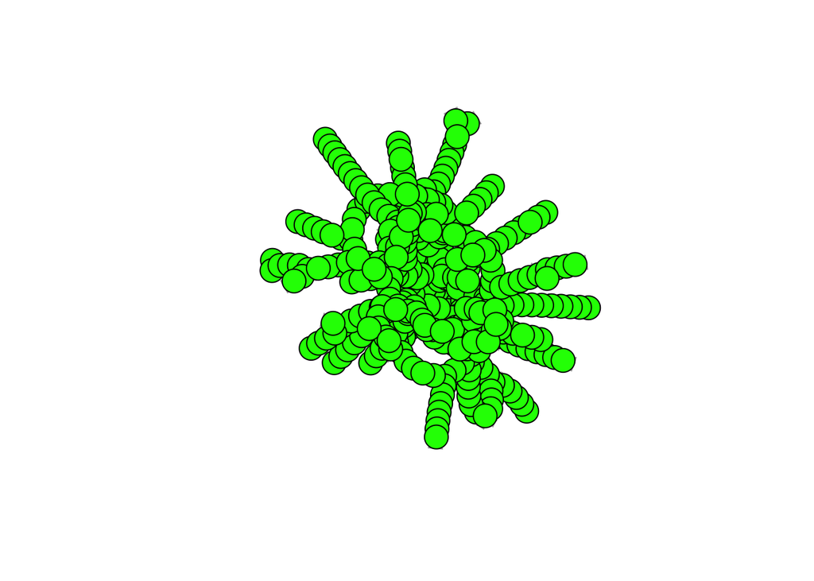

```r
plot.igraph(metro_graph, vertex.label = NA, layout=layout_with_kk, vertex.color="green")
```

Now let see how our graph can be represented using different layout structures so that we gain much deeper intution about the network.

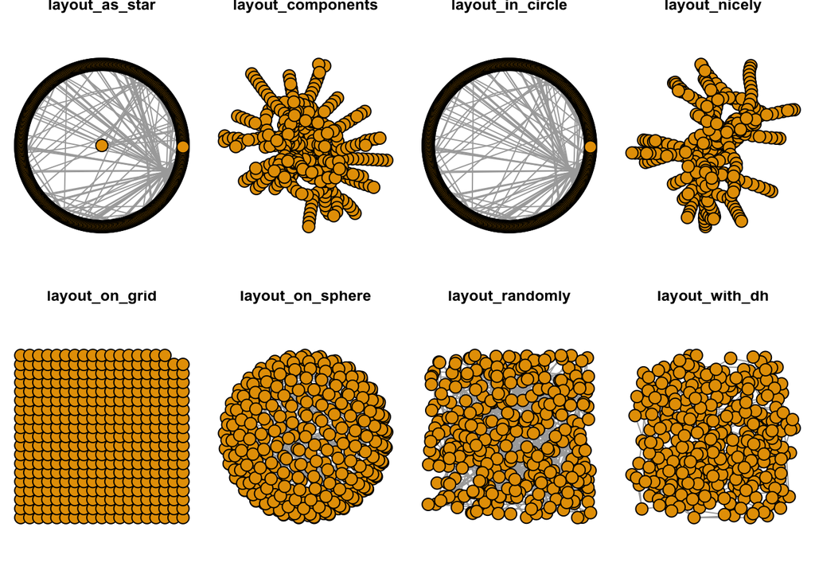

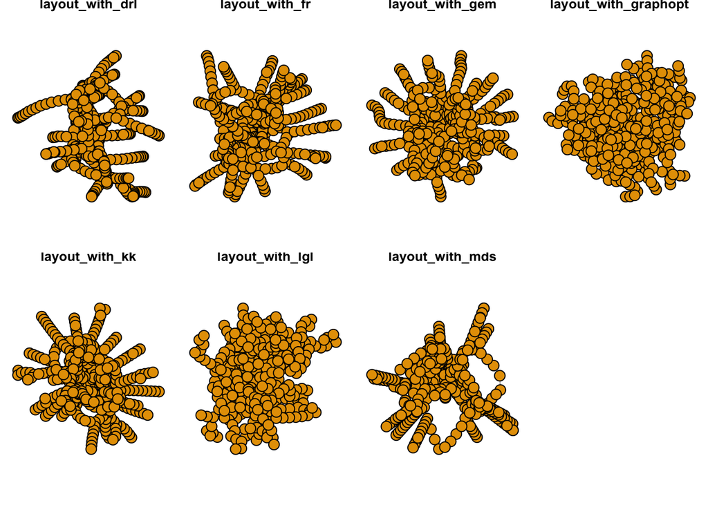